# scFeatureFilter:

# Testing `scFeatureFilter`

### Testing `scFeatureFilter` on more datasets:

.medium[16 datasets from [ConquerDB](http://imlspenticton.uzh.ch:3838/conquer/) (human and mouse)]

[figure not shown]

### `scFeatureFilter` on bulk RNA-seq:

48 repplicated bulk RNA-seq (yeast) (Gierliński et al., Bioinformatics, 2015)

[figure not shown]

# Limits of `scFeatureFilter`

### Lots of parameters?

|parameter           |description                                       |default|
|:-------------------|:-------------------------------------------------|------:|
|`max_zeros`         | maximum proportion of 0 for a feature to be kept |   0.75|
|`top_window_size`   | size of the reference set                        |    100|
|`other_window_size` | size of the other bins                           |   1000|
|`threshold`         | stringency of the selection                      |      2|

#
*vs* 1 or 2 parameters for arbitrary cut-off

### Lots of parameters?

The method is robust to `other_window_size`:

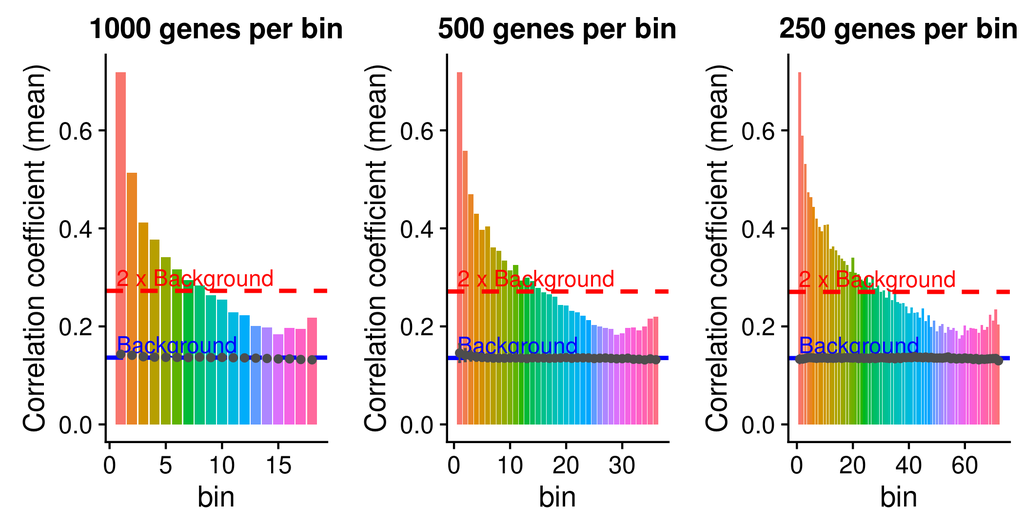

### Robust to `max_zeros`?

high proportion of 0s ~= low expression

- mostly not in the reference set

- more abundant in the low expression bins (filtered)

- less abundant in the high expression bins (ketp)

`threshold`: More or less stringency depending of the use cases and user preference.

### Lots of parameters?

`top_window_size` can have *massive* impact:

- if **too big**: Risk of selecting everything.
- if **too small**: Might not capture enough biological variation.

~100 seems to be a sweet spot on mouse and human data.

*Can we prove it?*

### Lots of parameters?

Average auto-correlation of the top window depending on its size:

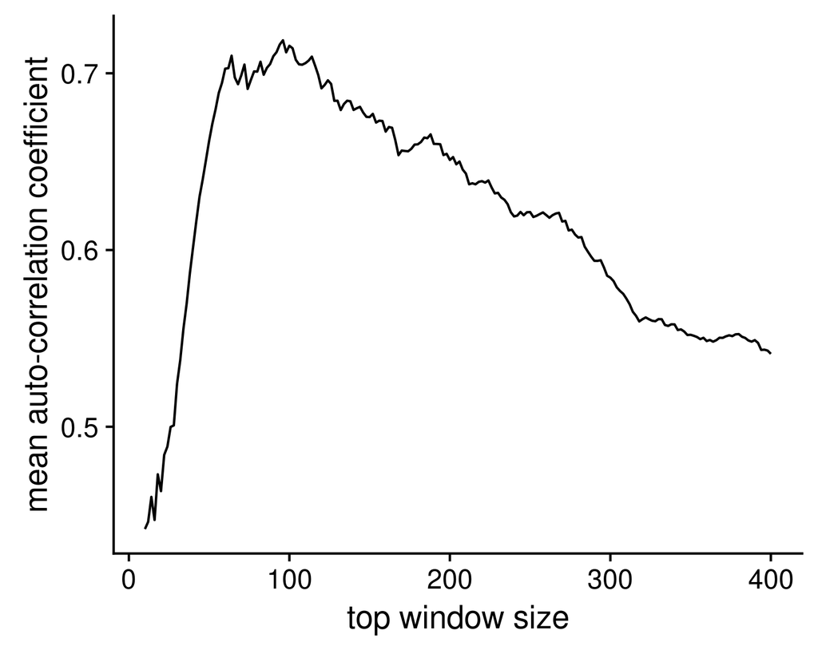

```r
plot_top_window_autocor(calculate_cvs(scData_hESC))
```

# Other limits?

- Tested on a dataset with 1378 cells. Scalable until when?

- Not designed nor tested for 10x genomics scRNA-seq.

# Conclusion:

`scFeatureFilter`: an R package for less arbitrary threshold selection

We are looking for feedback:
- Usefull?

- Overkilled?

- Broken assumptions?

- Better existing methods?

# Thanks

Anagha Joshi

Angeles Arzalluz-Luque

Anagha Joshi

Anna Mantsoki

[figure not shown]